# Methods 4 – Portfolio Assignment 2

- *Type:* Group assignment
- *Due:* 3 April 2022, 23:59

Hello CogSci’s :)

In this portfolio, you are asked to do four tasks:

- Make a DAG for something

- Simulate data that fits the DAG

- Use linear models to confirm that the DAG fits the data

- Mess it up.

Each of the four tasks have some sub-steps.  
Report briefly what you find, for example in a markdown document, for example called report.md so that the poor TA can easily get an overview before looking in your code :)

Then you can also make a (brief!) explanation of the phenomenon you are DAGGIN, simulating and modelling.

Looking forward !

## Task 1: The DAG

- **Come up with an** incredibly interesting and scientifically important made-up **example** for a phenomenon to investigate. Decide on two variables (an outcome and a predictor) that you would like to investigate the relation between. If in doubt, you **can be inspired by Peter’s amazing example** on the next page.

*Since Denmark reported it’s first case of COVID-19 contraction on the 27th February 2020 (STPS, 2020),* *COVID-19 and its development has been subject to extensive coverage in Danish media.* *News media has a critical role in times of epidemic crises since* *exposure to as well as consumption of information in times of pandemics* *may alter people’s perception and provoke behavioural changes that* *might ultimately impact the evolution and further spread of the virus (Gozzi et al., 2020).*

*We therefore expect that corona fear is a sensible predictor of whether one* *gets infected or not, assuming that the degree to which one fears* *COVID determines the precautions and actions one take to avoid getting infected.*

- **Make a DAG** for the phenomenon. Make it medium complicated: that means, make sure there are some different kinds of relations (see next step). Change it if you don’t get anything interesting for the next steps.  
**Draw it** somehow (on paper, in R, laser engraved in diamond).  
**Code it** in dagitty (this is a nice tool: http://dagitty.net/dags.html )

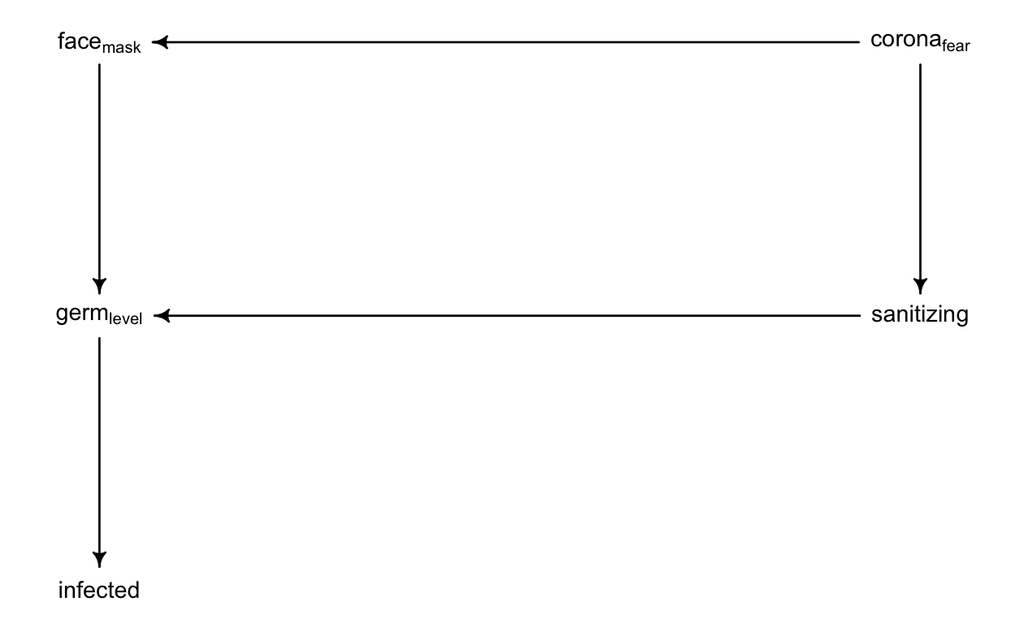

```r
pacman::p_load(usethis,dplyr, tidyverse, ggplot2, rstan, dagitty,ggdag)
library(rethinking)

#DAG corona
dag_corona<- dagitty( "dag {
    corona_fear -> sanitizing;
    sanitizing-> germ_level;
    face_mask -> germ_level;
    corona_fear -> face_mask;
    germ_level -> infected
}")

coordinates(dag_corona) <- list(
  x=c(corona_fear =0,face_mask =-1, sanitizing =0, germ_level=-1, infected= -1),
  y=c(corona_fear =0,face_mask =0, sanitizing = 1, germ_level=1, infected=2) )

drawdag(dag_corona)
```

[figure not shown]

```r
library(ggdag)

pretty_dag <- dagify(INF ~ GL,
      GL ~ FM + S,
      FM ~ CF,
      S ~ CF,
      labels = c("INF" = "Infected",
                 "FM" = "Face Mask",
                 "GL" = "Germ Level",
                 "CF" = "Corona Fear",
                 "S" = "Sanitising"),
      latent = c("FM","GL","S"), # latent variable = hidden variable
      exposure = "CF",
      outcome = "INF")

ggdag(pretty_dag, text = FALSE, use_labels = "label", stylized=FALSE)+remove_grid()+remove_axes()
```

[figure not shown]

```r
ggdag_paths(pretty_dag, text = FALSE, use_labels = "label", shadow = TRUE)
```

[figure not shown]

```r
ggdag_adjustment_set(pretty_dag, text = FALSE, use_labels = "label", shadow = TRUE)
```

[output not shown]

- Find **elemental forms of variable relations** in the DAG (i.e., forks, pipes, colliders, and their descendants).

Pipe

(FM -> GERM -> INFECTED)

(Cf –> FM –> GERM)

(CF -> S -> GERM)

(S –> GERM –> INFECTED)

Fork

(S <- CF -> FM)

Collider

(S -> GERM <- FM)

*We inspect the variable FM to depend on your corona fear, as we assume that a person who is really scared of COVID would be much more* *likely to strictly follow the national guidelines, whereas a person who didn’t fear corona at all would reversely be much less likely to* *wear a face mask although the national guidelines advises one to do it*

*The same goes for the relation between corona fear and sanitising. We expect a person with a high corona fear to have a much higher* *daily frequency of sanitising than a person with no corona fear at all*.

*We would expect germ level to depend on whether you wear face mask when advised to or not, as* *the face mask (at least partly) prevents germs from entering your mouth and nose*.

*The same goes for the relation between germ level and sanitising, as* *sanitising works by killing most germs, preventing them from entering your body*

*Lastly, we expect the level of germs to determine whether you are infected or not. With a low level of germs,* *one would expect your immune system would be strong enough to fight the few germs that have entered your body.* *However, if the level of germs in your body is extremely high, it might exceed the capacity of your immune system* *to fight back, resulting in you getting infected.*

- Find out **what variables to include (and not include)** in a multiple linear regression to avoid ‘back door’ (AKA non-causal) paths. Do this first with your eyes and your mind. Then you can use dagitty’s function `adjustmentSets()`.

```r
# Shutting the backdoor - analyzing the graph to block the backdoor
adjustmentSets(dag_corona,exposure="corona_fear", outcome="infected")
```

```
 {}
```

*OBS: nothing here = No backdoors to shut (no confounding paths between Corona Fear and Infected)*

Chris: our input is CF (predictor, our intervention), our outcome is (infected). We don’t have any backdoor paths, all paths are causal. If FM was a collider, it would be a common cause/confound that we would have to account for (hold constant) to close the backdown. We could aadd something that affects both FM and Germ_lvl. To have the total causal effect, we only need CF and Inf in out model (if we include FM and S, the coefficient for CF would just return the prior. Tge estimate for htis coefficient would be its own prior).

*You can ask your computer to reproduce this analysis, to analyze the graph and find the necessary variables to control for in order to block the backdoor. The dagitty R package provides adjustmentSets for this purpose*

In order to shut the backdoor. Here’s the recipe: (1) List all of the paths connecting X (the potential cause of interest) and Y (the out- come). (2) Classify each path by whether i t is open or closed. A path is open unless it contains a collider. (3) Classify each path by whether it is a backdoor path. A backdoor path has an arrow entering X. (4) If there are any backdoor paths that are also open, decide which variable(s) to con- dition on to close it. Let’s consider some examples.

- Find out which **conditional independencies** the DAG implies. First with the mind, then with daggity’s function `impliedConditionalIndependencies()`.

First, we find out which conditional independencies the DAG implies.

Pipe

(FM -> GERM -> INFECTED)

(Cf –> FM –> GERM)

(CF -> S -> GERM)

(S –> GERM –> INFECTED)

Fork

(S <- CF -> FM)

Collider

(S -> GERM <- FM)

```r
# Deriving our DAG’s conditional independencies
impliedConditionalIndependencies(dag_corona)
```

```
crn_ _||_ grm_ | fc_m, sntz
crn_ _||_ infc | grm_
crn_ _||_ infc | fc_m, sntz
fc_m _||_ infc | grm_
fc_m _||_ sntz | crn_
infc _||_ sntz | grm_
```

```
crn_ _||_ grm_ | fc_m, sntz

crn_ _||_ infc_ | grm_
*If we stratify by G, there is no association between CF and Infection*

crn_ _||_ infc_ | fc_m, sntz
*OBS*

fc_m _||_ infc_ | grm_
*OBS*

fc_m _||_ sntz | crn_
*OBS*

infc_ _||_ sntz | grm_
*OBS*
```

OBS: WE NEED TO EXPLAIN HERE. Chris said the following in the lecture of week 5: “there are a lot of implications of a DAG. There are different ways to test its implication. Use *dagitty* to get a list of testable implications (and go through this list one by one. If one of them is not fulfilled, you can falsify your DAG - but you can’t prove; you can only say *”This DAG is compatible with the data - there may be other DAGs"*.

p(FM)= S(CF)

CF is a continuum: as the fear increases, the probability of putting on mask increases. HOW do we simulate it? We can sim fear as normally distributed(0,1) which would give us a Gaussian. Then u say that whether a person puts on mask or not (FM) is rbern (1, sCP)).

P(FM) = 1/1+exp(CP). That you use!!!

Sigmoid transformation (from min if to if), but prob can only be from 0 to 1.

sCF (sigmoid transformation )

GL ~ rnorm(mu, sigma)

mu = b0+b1x1+b2x2

continuous –> bernomial (you translate to probability)

- Find the full list of **Markov equivalent** DAGS. Use daggity’s function `equivalentGraphs()`.

The equivalentGraphs() function outputs a set of DAGs with the same conditional independencies is known as a Markov equivalence set.

The list outputted allow show us 3 DAGS that would have the exact same conditional independencies as our dag_corona has.

```r
equivalentDAGs(dag_corona)
```

[output not shown]

Chris: We will get back the prior if we try to predict one thing from the other

## Task 2: The data

- **Simulate some data that fits the DAG.** There are many ways to do this. A simple way is just to sample one variable from a normal distribution which has another variable as mean. McElreath does this in the book a few times, and you can use this as inspiration.

*Corona Fear* Normal

*Face Mask* Binomial

*Sanitizing* Poisson

*Germ Level* Normal

*Infected* Binomial

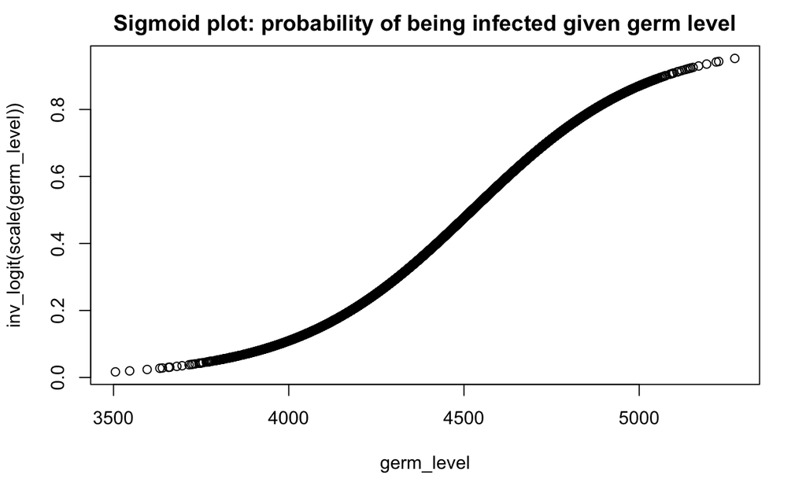

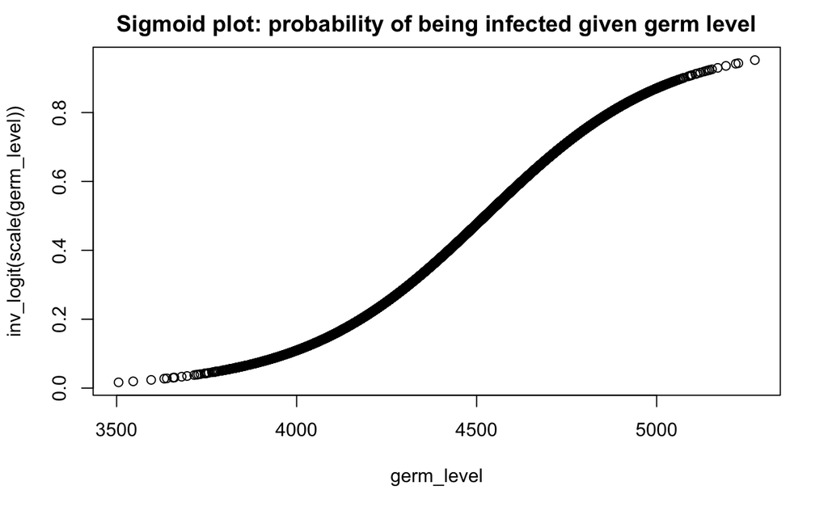

```r
plot(germ_level, inv_logit(scale(germ_level)), main= "Sigmoid plot: probability of being infected given germ level")
plot(germ_level, inv_logit(scale(germ_level)), main= "Sigmoid plot: probability of being infected given germ level")

# creating df
df <- tibble(germ_level, sanitizing, infected, face_mask, corona_fear)
```

*Standardizing variables* Standardizing variables: OBS CHRIS: SHOULD WE STANDARDIZE A DICHOTOMOUS VARIABLE, FM?

```r
df <- df %>%
  mutate(germ_std=scale(germ_level),sanitizing_std= scale(sanitizing),  infected_std=scale(infected),face_mask_std=scale(face_mask), corona_fear_std= scale(corona_fear))

ls.str(df)
```

```
corona_fear :  num [1:10000] 43.7 51.8 41.6 66 53.3 ...
corona_fear_std :  num [1:10000, 1] -0.612 0.188 -0.819 1.582 0.332 ...
face_mask :  int [1:10000] 0 1 0 1 1 0 1 1 1 0 ...
face_mask_std :  num [1:10000, 1] -1.001 0.999 -1.001 0.999 0.999 ...
germ_level :  num [1:10000] 4787 4326 4909 4068 4440 ...
germ_std :  num [1:10000, 1] 0.921 -0.728 1.36 -1.65 -0.318 ...
infected :  int [1:10000] 0 1 1 0 0 1 1 0 0 0 ...
infected_std :  num [1:10000, 1] -1.029 0.972 0.972 -1.029 -1.029 ...
sanitizing :  num [1:10000] 23.3 31.6 20.7 44.6 31.7 ...
sanitizing_std :  num [1:10000, 1] -0.646 0.16 -0.898 1.417 0.169 ...
```

## Task 3: Statistics

- Run **multiple linear regression**s to **test the conditional independencies** **implied by your DAG**. Make sure to avoid backdoor paths. See that the linear model shows the conditional independencies implied by your DAG, implying that the data and the DAG are compatible (if the linear model doesn’t show the conditional independencies implied by the DAG, the data and the DAG doesn’t fit).

### Testing the conditional independencies

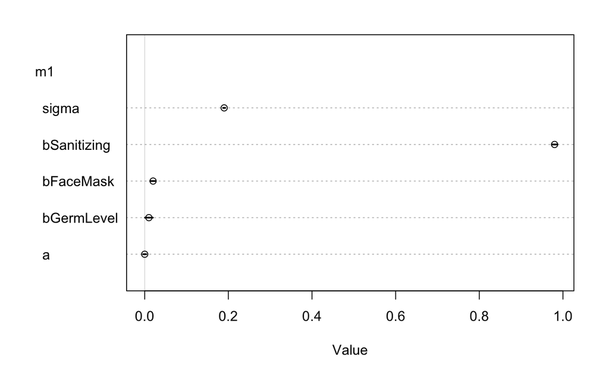

Model 2: crn_ *||* infc | grm_ Testing whether the causal coefficient infc (being infected or not) is insignificant when stratifying by germ_level.

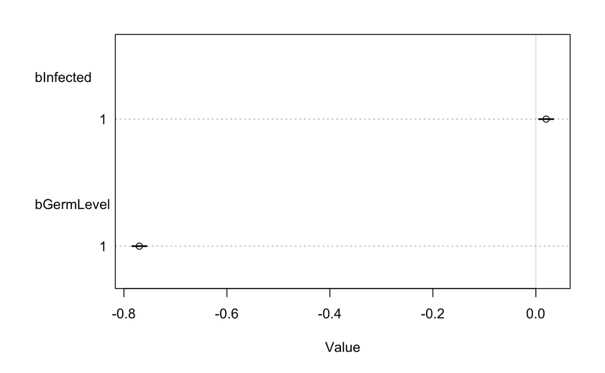

```r
m2<- quap(
    alist(
        corona_fear_std ~ dnorm( mu , sigma ) ,
        mu <- a + bInfected*infected_std  + bGermLevel*germ_std,
        a ~ dnorm( 0 , 0.2 ) ,
        bInfected ~ dnorm( 0 , 1 ) ,
        bGermLevel~ dnorm( 0 , 1 ),
        sigma ~ dexp( 1 )
    ) , data = df )

plot(coeftab(m2), par=c("bInfected", "bGermLevel" ))
```

As seen in the above plot, corona fear and infected becomes independent (i.e., the model confidently estimates the coefficient bInfected to be very close to zero) when stratifying by germ_level.

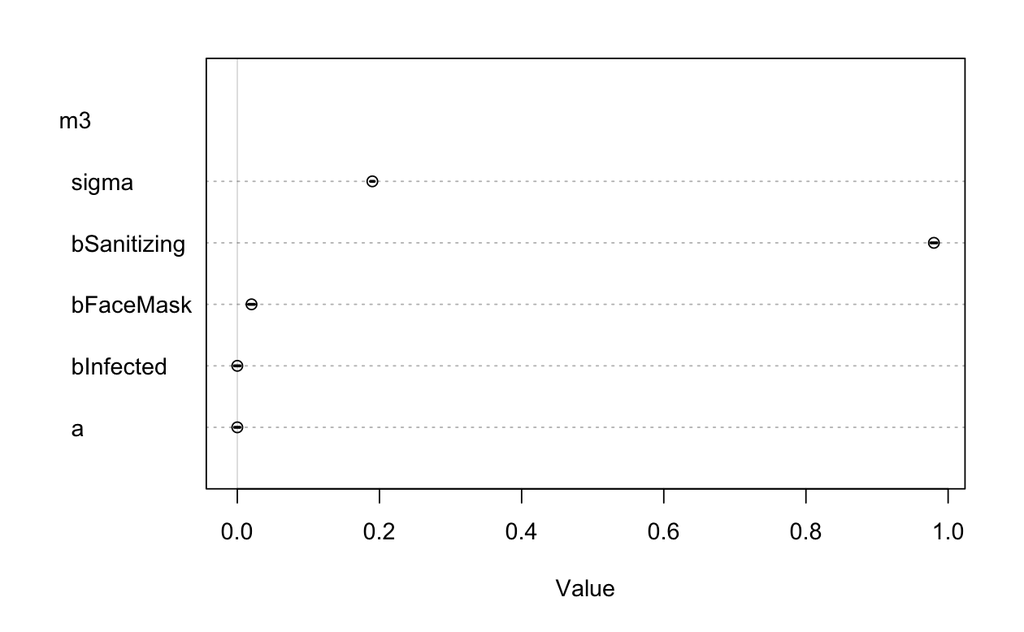

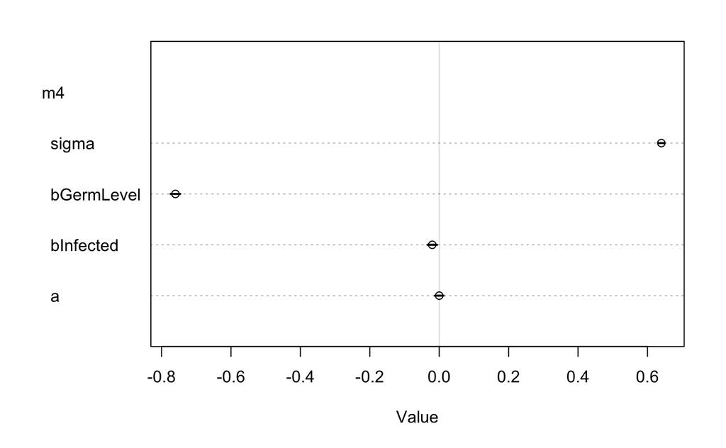

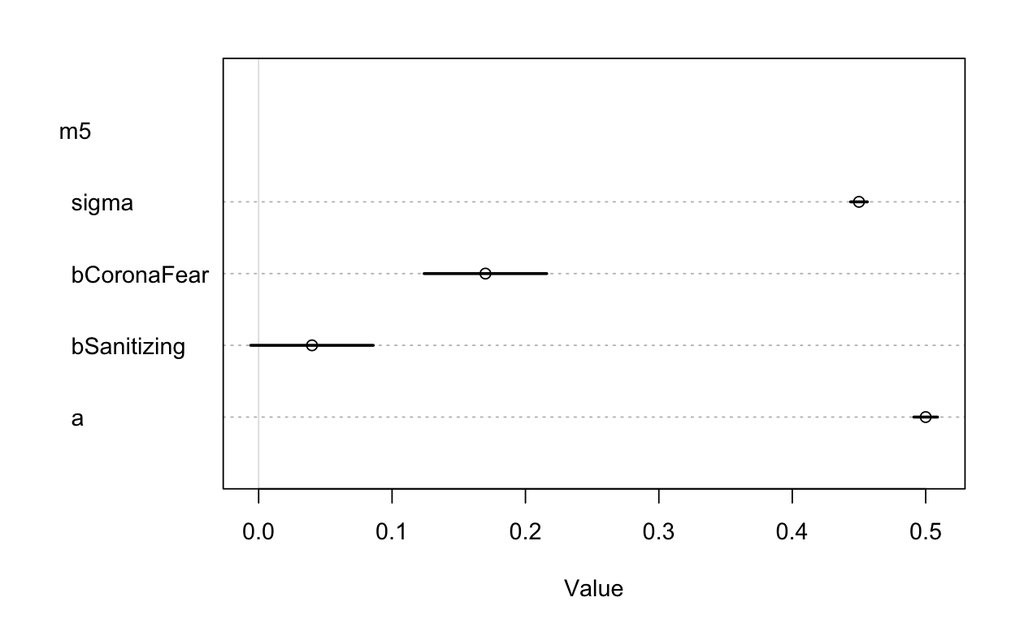

```r
m5 <- quap(
    alist(
        face_mask ~ dnorm( mu , sigma ) ,
        mu <- a + bSanitizing*sanitizing_std  + bCoronaFear*corona_fear_std,
        a ~ dnorm( 0 , 0.2 ) ,
        bSanitizing ~ dnorm( 0 , 1 ) ,
        bCoronaFear~ dnorm( 0 , 1 ),
        sigma ~ dexp( 1 )
    ) , data = df )

plot(coeftab(m5),by.model=TRUE)
```

The coefficient bSanitizing is still close to zero, but not as confidently estimated as zero as in the previous plots. OBS CHRIS: can we say that the coefficient bSanitizing is close to zero (thus in accordance with our dag), or does such as small deviation from 0 count as a violation of the implications of our DAG????

Model 6: infc_ *||* sntz | grm_ Testing whether the causal coefficient of sanitizing becomes significantly close to zero when stratifying by germ level in a model that has infected as outcome variable.

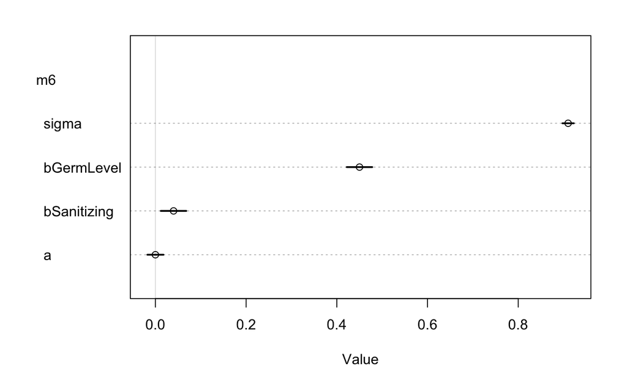

## Task 4: Messing it up

- Try and **deliberately have an open back door path** and see if you can get wrong inference.

We now create a DAG that has the variable OCD as backdoor that directly influences both corona fear and sanitizing. We expect a person with severe OCD sanitize more often (independently of corona fear), but also to fear corona more, which then has a direct influence on sanitizing as well.

```r
# Shutting the backdoor - analyzing the graph to block the backdoor
adjustmentSets(twisted_dag_corona, exposure="corona_fear", outcome="infected")
```

```
{ OCD }
```

Including OCD introduces an open backdoor path to infected. OCD is a confounded variable that may result in our model making wrong inferences. When introducing OCD in the DAG, OCD creates a confounding path going from OCD –> SAN –> GL –> INF. We want to block it in order to avoid any spurious correlation that prevents us from seeing the actual effect that corona_fear has on infection.

The path CF <- OCD -> sanitizing is a backdoor path because it enters corona fear with an arrow and also connects corona fear to sanitizing. This path is confounding.We can deconfound this model by stratifying by OCD. Since sanitizing and corona fear in the above dag share the common cause, OCD, we can separate them statistically by stratifying by their common cause, OCD.

- Try and deliberately **simulate some data that doesn’t fit the DAG**, or **create a new DAG that doesn’t fit the data**.

```r
# Corona fear (assuming that it is normally distributed)
corona_fear_w <-rnorm(N, mean=50, sd=10)

# Face mask (depending on germ level)
face_mask_w <- rbinom(N, size =1, prob= inv_logit(scale(germ_level)))

# Sanitizing (depending on germ_level)
sanitizing_w <- rnorm(N, mean= germ_level-20, sd=2)

# Germ level (depending on corona fear and face mask)
germ_level_w <-  rnorm(N, mean= 5000 - ((corona_fear*10)*(1+face_mask)), sd=100)

# Infected (not depending on any of the variables)
infected_w <-  rbinom(N, size= 1, prob=0.2)


# OCD level
OCD_w <- sample(1:5, size=N, replace=TRUE, prob=c(.8, .10, .05, .03, .02)) # 80% of not having OCD, apx. 2% chance for severe OCD

# creating df
df_w <- tibble(germ_level_w, sanitizing_w, infected_w, face_mask_w, corona_fear_w, OCD_w)
```

### Standardizing variables: OBS CHRIS: SHOULD WE STANDARDIZE A DICHOTOMOUS VARIABLE, FM?

```r
df_w <- df_w %>%
  mutate(germ_std_w=scale(germ_level_w),sanitizing_std_w= scale(sanitizing_w),  infected_std_w=scale(infected_w),face_mask_std_w=scale(face_mask_w), corona_fear_std_w= scale(corona_fear_w), OCD_std_w = scale(OCD_w))
```

### Implied conditional independencies

```r
impliedConditionalIndependencies(twisted_dag_corona)
```

```
OCD _||_ fc_m | crn_
OCD _||_ grm_ | fc_m, sntz
OCD _||_ grm_ | crn_, sntz
OCD _||_ infc | grm_
OCD _||_ infc | fc_m, sntz
OCD _||_ infc | crn_, sntz
crn_ _||_ grm_ | fc_m, sntz
crn_ _||_ infc | grm_
crn_ _||_ infc | fc_m, sntz
fc_m _||_ infc | grm_
fc_m _||_ sntz | crn_
infc _||_ sntz | grm_
```

OCD *||* fc_m | crn_ OCD *||* grm_ | fc_m, sntz OCD *||* grm_ | crn_, sntz OCD *||* infc | grm_ OCD *||* infc | fc_m, sntz OCD *||* infc | crn_, sntz

### Testing implied conditional independencies

```r
######### MODEL 1 wrong ################
# OCD _||_ fc_m | crn_
model1_w <- quap(
    alist(
        OCD_std_w ~ dnorm( mu , sigma ) ,
        mu <- a + bFaceMask*social_exposure_std_w + bCoronaFear*corona_fear_std_w,
        a ~ dnorm( 0 , 0.2 ) ,
        bCoronaFear ~ dnorm( 0 , 0.5 ) ,
        bFaceMask ~ dnorm( 0 , 0.5 ) ,
        sigma ~ dexp( 1 ) # OBS : why exp? It doesn't change anything changing it to dnorm or dunif
    ) , data = df_w )

precis( model1_w )

plot(precis( model1_w ))

######### MODEL 2 wrong ################
# crn_ _||_ grm_ | fc_m, sntz
# OCD _||_ grm_ | fc_m, sntz
model2_w <- quap(
    alist(
        OCD_std_w ~ dnorm( mu , sigma ) ,
        mu <- a + bGermLevel*germ_std_w + bFaceMask*social_exposure_std_w + bSanitize*sanitizing_std_w ,
        a ~ dnorm( 0 , 0.2 ) ,
        bGermLevel ~ dnorm( 0 , 0.5 ) ,
        bFaceMask ~ dnorm( 0 , 0.5 ) ,
        bSanitize ~ dunif( 0 , 0.5 ) ,
        sigma ~ dexp( 1 ) # OBS : why exp? It doesn't change anything changing it to dnorm or dunif
    ) , data = df_w )

precis( model2_w )

plot(precis( model2_w ))

#### MODEL 3
#OCD || grm_ | crn_, sntz
model3_w<- quap(
    alist(
        OCD_std_w ~ dnorm( mu , sigma ) ,
        mu <- a  + bGermLevel*germ_std_w + bCoronaFear*corona_fear_std_w+ bSanitizing*sanitizing_std_w,
        a ~ dnorm( 0 , 0.2 ) ,
        bGermLevel~ dnorm( 0 , 1 ) ,
        bCoronaFear~ dnorm( 0 , 1 ),
        bSanitizing ~ dnorm( 0 , 1 ),
        sigma ~ dexp( 1 )
    ) , data = df_w )
precis(model3_w)

plot(coeftab(model3_w),by.model=TRUE )

#### MODEL 4
#OCD || infc | grm_
model4_w<- quap(
    alist(
        OCD_std_w ~ dnorm( mu , sigma ) ,
        mu <- a  + bInfected*infected_std_w + bGermLevel*germ_std_w,
        a ~ dnorm( 0 , 0.2 ) ,
        bInfected ~ dnorm( 0 , 1 ),
        bGermLevel~ dnorm( 0 , 1 ) ,
        sigma ~ dexp( 1 )
    ) , data = df_w )

precis(model4_w)
plot(coeftab(model4_w),by.model=TRUE )


#### MODEL 5
# OCD _||_ infc | fc_m, sntz # 5

model5_w<- quap(
    alist(
        OCD_std_w ~ dnorm( mu , sigma ) ,
        mu <- a + bInfected*infected_std_w  + bsocial_exposure*social_exposure_std_w + bSanitizing*sanitizing_std_w,
        a ~ dnorm( 0 , 0.2 ) ,
        bInfected~ dnorm( 0 , 1 ) ,
        bsocial_exposure~ dnorm( 0 , 1 ),
        bSanitizing~ dnorm( 0 , 1 ),
        sigma ~ dexp( 1 )
    ) , data = df_w )
precis( model5_w)

plot(precis(model5_w))

#### MODEL 6
# OCD _||_ infc | crn_, sntz # 6
model6_w<- quap(
    alist(
        OCD_std_w ~ dnorm( mu , sigma ) ,
        mu <- a + benergylvl*infected_std_w  + bCorona_fear*corona_fear_std_w + bSanitizing*sanitizing_std_w,
        a ~ dnorm( 0 , 0.2 ) ,
        bInfected~ dnorm( 0 , 1 ) ,
        bCorona_fear~ dnorm( 0 , 1 ),
        bSanitizing~ dnorm( 0 , 1 ),
        sigma ~ dexp( 1 )
    ) , data = df_w )
precis( model6_w)

plot(precis(model6_w))
```

[output not shown]

## Peter’s perfectly optimal and extremely interesting example

*In a galaxy far, far away…*

*It is a period of civil wars in the galaxy. A brave alliance of underground freedom fighters has challenged the tyranny and oppression of the awesome GALACTIC EMPIRE.*

*To crush the rebellion once and for all, the EMPIRE is constructing a sinister new battle station. Powerful enough to destroy an entire planet, its completion spells certain doom for the champions of freedom.*

*The evil Emperor has figured out, however, that neither the battle station nor the Force can help him avoid that more solar systems join the rebellion. He has therefore hired a CogSci student to use causal modelling and multiple linear regressions to investigate how the activity of the Death Star and other factors affects the probability that a given solar system will join the rebellion (this allows him to more optimally suppress freedom in the Galaxy).*

*You are that student.*

We assume that the probability of a solar system joining the rebellion depends on  
- how many rebellion sympathizers there is in the system (more rebels -> higher probability of joining the rebellion)  
- how scared people are in the system (more scared -> lower probability of joining the rebellion).

How many rebellion sympathizers there is in a system depends on

- crime levels (less crime -> less rebellion sympathizers)

- number of planets recently destroyed by the Death Star (more planets destroyed -> more rebellion sympathizers)

- number of Jedis in the system (more Jedis -> more rebellion sympathizers)

How scared people are depends on

- whether or not the Death Star is nearby (nearby -> more scared)

- how many jedis are in the system (more Jedis -> less scared)

- how much time Darth Vader has spent in the system recently (more time -> more scared)

Crime levels depend on

- number of planets recently destroyed by the Death Star (more planets destroyed -> less crime)

And so on….

# References

STPS, S. F. P. (2020, February 27). Første dansker er bekræftet smittet med COVID-19 (ny coronavirus)—Styrelsen for Patientsikkerhed. https://stps.dk/da/nyheder/2020/foerste- dansker-er-bekraeftet-smittet-med-covid-19-ny-coronavirus/

Gozzi, N., Tizzani, M., Starnini, M., Ciulla, F., Paolotti, D., Panisson, A., & Perra, N. (2020). Collective Response to Media Coverage of the COVID-19 Pandemic on Reddit and Wikipedia: Mixed-Methods Analysis. Journal of Medical Internet Research, 22(10), e21597. https://doi.org/10.2196/21597